# Part I - (Ford GO bike - trip data : Full exploration)

## Introduction

The dataset used in this project is the Ford GoBike System Dataset for February 2019. Ford GoBike is a regional public bicycle sharing system in the San Francisco Bay Area. The dataset includes information about individual rides made in the bike-sharing system, encompassing details about the trip's start and end times, the starting and ending locations, and user characteristics such as gender, age, and user type (subscriber or customer). This project aims to explore the dataset systematically, using data visualization techniques to uncover interesting patterns, trends, and relationships. The primary focus will be on understanding the behavior of bike-sharing users and identifying factors that influence ride durations and trip patterns.

Key questions to explore:

What are the most popular times of day for bike rides? How does ride duration vary with different user types? Are there any notable differences in ride patterns between weekdays and weekends? What impact does the rider's age have on trip duration? Are there any correlations between the start or end locations and the trip duration? By answering these questions, we aim to gain insights into the usage patterns of the Ford GoBike system and provide actionable recommendations to improve the service.

> **Rubric Tip**: Your code should not generate any errors, and should use functions, loops where possible to reduce repetitive code. Prefer to use functions to reuse code statements.

> **Rubric Tip**: Document your approach and findings in markdown cells. Use comments and docstrings in code cells to document the code functionality.

> **Rubric Tip**: Markup cells should have headers and text that organize your thoughts, findings, and what you plan on investigating next.

## Preliminary Wrangling

```python
# import all packages and set plots to be embedded inline
import numpy as np
import pandas as pd
import matplotlib.pyplot as plt
import seaborn as sns
```

```python
df = pd.read_csv('201902-fordgobike-tripdata.csv')

# Display the first few rows of the dataset
df.head()
```

|  | duration_sec | start_time | end_time | start_station_id | start_station_name | start_station_latitude | start_station_longitude | end_station_id | end_station_name | end_station_latitude | end_station_longitude | bike_id | user_type | member_birth_year | member_gender | bike_share_for_all_trip |
| --- | --- | --- | --- | --- | --- | --- | --- | --- | --- | --- | --- | --- | --- | --- | --- | --- |
| 0 | 52185 | 2019-02-28 17:32:10.1450 | 2019-03-01 08:01:55.9750 | 21.0 | Montgomery St BART Station (Market St at 2nd St) | 37.789625 | -122.400811 | 13.0 | Commercial St at Montgomery St | 37.794231 | -122.402923 | 4902 | Customer | 1984.0 | Male | No |
| 1 | 42521 | 2019-02-28 18:53:21.7890 | 2019-03-01 06:42:03.0560 | 23.0 | The Embarcadero at Steuart St | 37.791464 | -122.391034 | 81.0 | Berry St at 4th St | 37.775880 | -122.393170 | 2535 | Customer | NaN | NaN | No |
| 2 | 61854 | 2019-02-28 12:13:13.2180 | 2019-03-01 05:24:08.1460 | 86.0 | Market St at Dolores St | 37.769305 | -122.426826 | 3.0 | Powell St BART Station (Market St at 4th St) | 37.786375 | -122.404904 | 5905 | Customer | 1972.0 | Male | No |
| 3 | 36490 | 2019-02-28 17:54:26.0100 | 2019-03-01 04:02:36.8420 | 375.0 | Grove St at Masonic Ave | 37.774836 | -122.446546 | 70.0 | Central Ave at Fell St | 37.773311 | -122.444293 | 6638 | Subscriber | 1989.0 | Other | No |
| 4 | 1585 | 2019-02-28 23:54:18.5490 | 2019-03-01 00:20:44.0740 | 7.0 | Frank H Ogawa Plaza | 37.804562 | -122.271738 | 222.0 | 10th Ave at E 15th St | 37.792714 | -122.248780 | 4898 | Subscriber | 1974.0 | Male | Yes |

### Structure of the dataset :

```python
# Display the structure of the dataset
df.info()
```

```
<class 'pandas.core.frame.DataFrame'>
RangeIndex: 183412 entries, 0 to 183411
Data columns (total 16 columns):
 #   Column                   Non-Null Count   Dtype
---  ------                   --------------   -----
 0   duration_sec             183412 non-null  int64
 1   start_time               183412 non-null  object
 2   end_time                 183412 non-null  object
 3   start_station_id         183215 non-null  float64
 4   start_station_name       183215 non-null  object
 5   start_station_latitude   183412 non-null  float64
 6   start_station_longitude  183412 non-null  float64
 7   end_station_id           183215 non-null  float64
 8   end_station_name         183215 non-null  object
 9   end_station_latitude     183412 non-null  float64
 10  end_station_longitude    183412 non-null  float64
 11  bike_id                  183412 non-null  int64
 12  user_type                183412 non-null  object
 13  member_birth_year        175147 non-null  float64
 14  member_gender            175147 non-null  object
 15  bike_share_for_all_trip  183412 non-null  object
dtypes: float64(7), int64(2), object(7)
memory usage: 22.4+ MB
```

### What is/are the main feature(s) of interest in your dataset?

The main feature(s) of interest in the dataset are those that can provide insights into how the Ford GoBike system is used, particularly focusing on user behavior, temporal patterns, and spatial data. Here's a summary of the key features of interest:

1-duration_sec:

This feature represents the duration of each bike ride in seconds. It is essential for understanding the length of trips, which can be correlated with factors like user type, time of day, and demographics.

2-start_time and end_time:

These timestamps indicate when each ride started and ended. They are crucial for analyzing temporal patterns, such as peak usage times, day-of-week trends, and seasonal variations in bike usage.

3-start_station_name and end_station_name:

These features represent the names of the stations where rides begin and end. They are vital for exploring spatial patterns, such as the most popular stations, and for understanding the flow of bike traffic across different parts of the city.

4-user_type:

This feature indicates whether a rider is a "Subscriber" (typically someone with a membership) or a "Customer" (a casual user). Understanding how these different user types engage with the bike-sharing service can reveal important insights into usage patterns and preferences.

5-member_gender and member_birth_year:

These demographic features provide information on the gender and age of users. Analyzing these variables in conjunction with ride duration and frequency can help uncover trends related to age and gender differences in bike-sharing behavior.

6-bike_id:

Although not the primary focus, this feature tracks the specific bike used for each ride. It can be useful for understanding bike utilization rates and maintenance needs.

### Exploration Focus

The analysis will focus on how these features interact with each other to reveal patterns and trends in the usage of the Ford GoBike system. For example:

Temporal Analysis: Examining how duration_sec varies across different times (start_time, end_time) can highlight peak usage periods. User Behavior: Comparing duration_sec and ride frequency between user_type groups can show differences in how subscribers and customers use the service. Spatial Patterns: Analyzing start_station_name and end_station_name can identify the most popular locations and potential patterns in ride flow across the city. Demographic Insights: Looking at member_gender and member_birth_year in relation to trip duration and frequency may uncover demographic trends in bike-sharing usage. These features will guide the exploration and help uncover meaningful insights about the Ford GoBike system

### What features in the dataset do you think will help support your investigation into your feature(s) of interest?

To support the investigation into the main features of interest, the following supporting features in the dataset will be crucial:

- start_time and end_time:

These features provide precise temporal data, allowing for an analysis of when trips occur. This will help in understanding patterns such as peak usage hours, differences in usage on weekdays versus weekends, and seasonal variations.

- start_station_id and end_station_id:

These features are the corresponding identifiers for start_station_name and end_station_name. They are useful for spatial analysis and for ensuring accuracy when tracking station-specific patterns.

- start_station_latitude, start_station_longitude, end_station_latitude, and end_station_longitude:

These geographic coordinates enable a more detailed spatial analysis, such as mapping the most common routes and identifying areas with high or low usage. They can also help in visualizing the spatial distribution of trips across the city.

- user_type:

This feature distinguishes between Subscribers and Customers, which is key to understanding differences in behavior between these two groups, such as trip duration, frequency, and station preferences.

- member_birth_year:

This feature allows for age-based analysis, helping to identify if certain age groups use the bike-sharing service more frequently or have different usage patterns.

- member_gender:

This feature will be used to explore gender-based differences in bike usage, such as trip duration and station preferences.

- bike_id:

While not a primary focus, this feature can support the investigation by allowing for analysis of bike utilization rates. It might reveal patterns in how often specific bikes are used, which can be tied to maintenance schedules or bike longevity.

### Functions to make a clean code

```python
import matplotlib.pyplot as plt
import seaborn as sns
import numpy as np
import pandas as pd

def plot_distribution_histogram(df, column, bins, x_label, y_label, title, xlim=None, color='skyblue'):
    plt.figure(figsize=(8, 6))
    plt.hist(data=df, x=column, bins=bins, color=color, edgecolor='black')
    plt.title(title)
    plt.xlabel(x_label)
    plt.ylabel(y_label)
    if xlim:
        plt.xlim(xlim)
    plt.show()

def plot_countplot(df, column, x_label, y_label, title, palette='viridis'):
    plt.figure(figsize=(6, 4))
    sns.countplot(data=df, x=column, palette=palette)
    plt.title(title)
    plt.xlabel(x_label)
    plt.ylabel(y_label)
    plt.show()

def plot_boxplot(df, x_column, y_column, x_label, y_label, title):
    plt.figure(figsize=(10, 6))
    sns.boxplot(data=df, x=x_column, y=y_column)
    plt.title(title)
    plt.xlabel(x_label)
    plt.ylabel(y_label)
    plt.show()

def plot_scatterplot(df, x_column, y_column, x_label, y_label, title, alpha=0.3):
    plt.figure(figsize=(10, 6))
    sns.scatterplot(data=df, x=x_column, y=y_column, alpha=alpha)
    plt.title(title)
    plt.xlabel(x_label)
    plt.ylabel(y_label)
    plt.show()

def plot_histogram_with_hue(df, x_column, hue_column, x_label, y_label, title, bins=24):
    plt.figure(figsize=(12, 8))
    sns.histplot(data=df, x=x_column, hue=hue_column, multiple='dodge', bins=bins)
    plt.title(title)
    plt.xlabel(x_label)
    plt.ylabel(y_label)
    plt.show()
```

## 1. Question: What is the distribution of trip durations in the dataset?

Visualization:

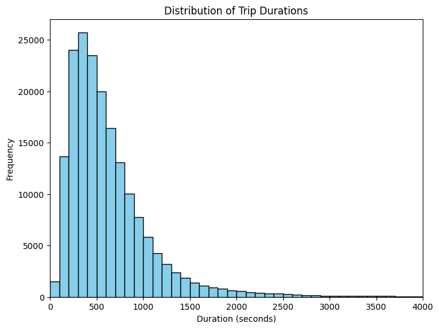

```python
# Plot 1: Distribution of Trip Durations
bins = np.arange(0, df['duration_sec'].max()+100, 100)
plot_distribution_histogram(df, 'duration_sec', bins, 'Duration (seconds)', 'Frequency', 'Distribution of Trip Durations', xlim=(0, 4000))
```

Observations:

- The majority of trips are short, lasting between 0 and 2000 seconds.
- The distribution has a long tail to the right, indicating some trips are significantly longer.
- Most trips are under 5000 seconds, suggesting that outliers might need further investigation.

## 2. Question: What is the distribution of user types?

visualization:

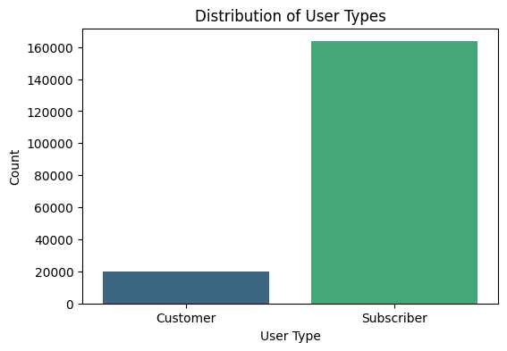

```python
# Plot 2: Distribution of User Types
plot_countplot(df, 'user_type', 'User Type', 'Count', 'Distribution of User Types')
```

Observations:

- The dataset is predominantly composed of Subscribers, with fewer Customers.
- This suggests a large portion of users are regular, repeat users rather than occasional riders.

## 3. Question: How is gender distributed among the members?

visualization:

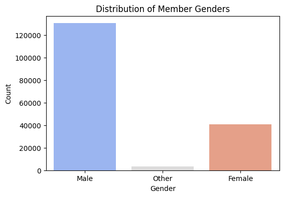

```python
# Plot 3: Distribution of Member Genders
plot_countplot(df, 'member_gender', 'Gender', 'Count', 'Distribution of Member Genders', palette='coolwarm')
```

Observations:

## 4. Question: What is the age distribution of the users?

Visualization:

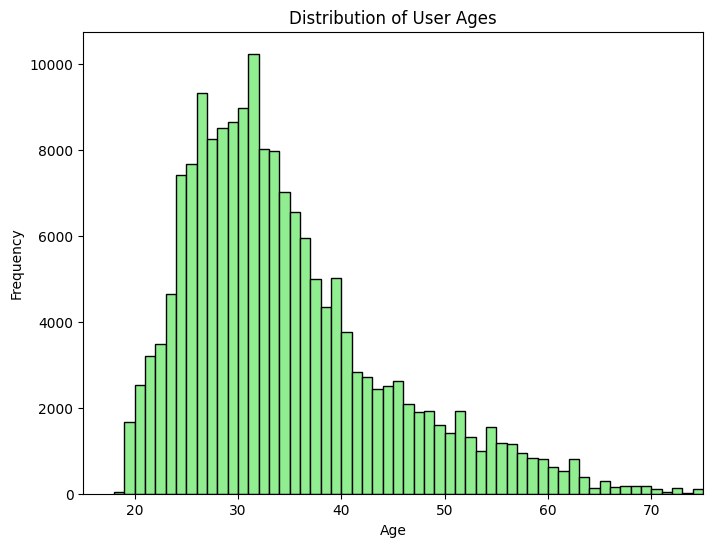

```python
# Plot 4: Distribution of User Ages
df['age'] = 2019 - df['member_birth_year']
bins = np.arange(df['age'].min(), df['age'].max()+1, 1)
plot_distribution_histogram(df, 'age', bins, 'Age', 'Frequency', 'Distribution of User Ages', xlim=(15, 75), color='lightgreen')
```

Observations:

- Most users are between 20 and 40 years old.
- The data shows some outliers on both ends of the age spectrum, possibly due to incorrect or incomplete data entries.

## 5. Question: When are most trips initiated during the day?

Visuzalization:

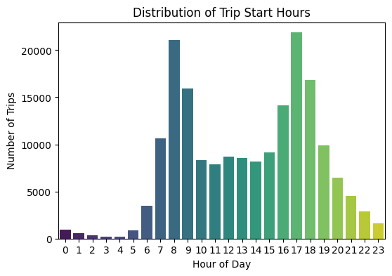

```python
# Plot 5: Distribution of Trip Start Hours
df['start_time'] = pd.to_datetime(df['start_time'])
df['start_hour'] = df['start_time'].dt.hour
plot_countplot(df, 'start_hour', 'Hour of Day', 'Number of Trips', 'Distribution of Trip Start Hours', palette='viridis')
```

Observations:

- Most trips start during commuting hours, with peaks around 8 AM and 5-6 PM.
- There is a noticeable decline in trips during late-night hours, consistent with expected user behavior.

### Discuss the distribution(s) of your variable(s) of interest. Were there any unusual points? Did you need to perform any transformations?

> The primary variable of interest, duration_sec (duration of bike trips in seconds), exhibited a right-skewed distribution. Most trips were concentrated around shorter durations, with a long tail extending towards longer trips. To better understand this distribution, I applied a logarithmic transformation, which helped to normalize the skewness and made it easier to observe patterns in trip durations. This transformation was essential for reducing the impact of outliers and for facilitating the comparison of trip durations across different factors.

### Of the features you investigated, were there any unusual distributions? Did you perform any operations on the data to tidy, adjust, or change the form of the data? If so, why did you do this?

> Yes, in addition to duration_sec, the member_gender feature showed an imbalance in the distribution of values, with more male users than female users. No transformations were necessary for this variable, but this observation is crucial when analyzing patterns related to gender. The duration_sec variable required a logarithmic transformation due to its right-skewed nature, which helped in handling the outliers and provided a clearer view of the data's central tendency.

## 1. Question: Is there a relationship between trip duration and user type (Subscriber vs. Customer)?

Visualization:

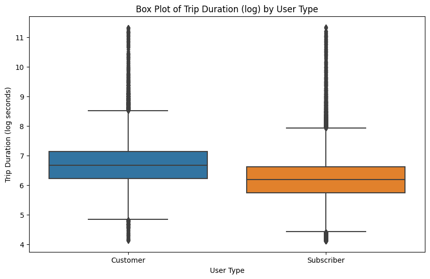

```python
# Plot 6: Box Plot of Trip Duration (log) by User Type
df['log_duration_sec'] = np.log(df['duration_sec'])
plot_boxplot(df, 'user_type', 'log_duration_sec', 'User Type', 'Trip Duration (log seconds)', 'Box Plot of Trip Duration (log) by User Type')
```

Observation:

- The distribution of trip duration varies between different user types.
- Subscribers generally have shorter trip durations compared to customers. This could indicate that subscribers use the service for shorter, more frequent trips, whereas customers might use it for longer trips.

## 2. Question: Is there a relationship between the age of the user and the duration of the trip?

Visualization:

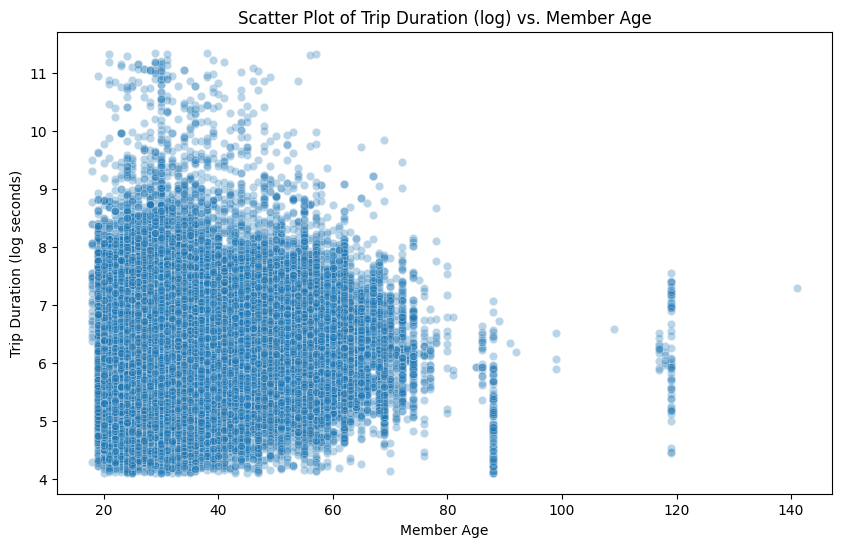

```python
# Plot 7: Scatter Plot of Trip Duration (log) vs. Member Age
df['member_age'] = 2019 - df['member_birth_year']
plot_scatterplot(df, 'member_age', 'log_duration_sec', 'Member Age', 'Trip Duration (log seconds)', 'Scatter Plot of Trip Duration (log) vs. Member Age')
```

Observations:

- There is no relation based on this graph

## 3. Question: How does the trip start hour distribution differ between user types?

Visualization

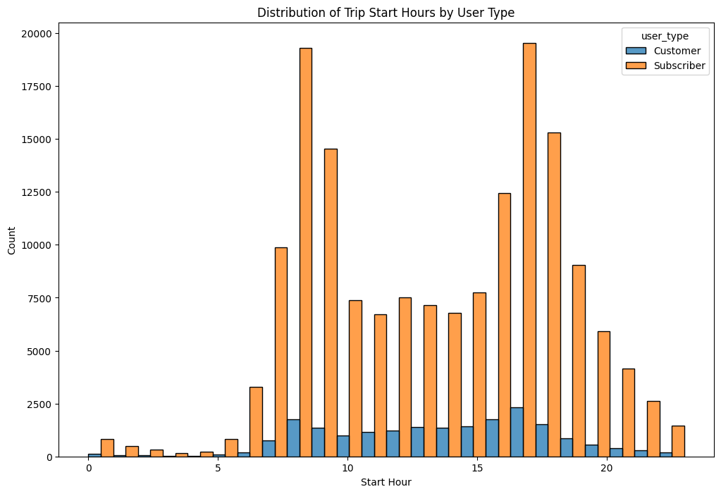

```python
# Plot 8: Distribution of Trip Start Hours by User Type
plot_histogram_with_hue(df, 'start_hour', 'user_type', 'Start Hour', 'Count', 'Distribution of Trip Start Hours by User Type')
```

Observations:

- Both subscribers and customers have peak trip times during the morning and evening rush hours, but subscribers have a more pronounced peak during these times, possibly due to commuting patterns.

### Talk about some of the relationships you observed in this part of the investigation. How did the feature(s) of interest vary with other features in the dataset?

> Trip Duration vs. User Type: The trip duration (log-transformed) varied notably between different user types. Specifically, subscribers tend to have shorter trip durations compared to customers. This pattern suggests that subscribers may be using the service for more routine, shorter trips, such as commuting, while customers might use the service for longer, less frequent trips, potentially for leisure or tourism purposes.

### Did you observe any interesting relationships between the other features (not the main feature(s) of interest)?

> Start Hour vs. User Type: The distribution of trip start hours revealed interesting patterns. Both subscribers and customers had peak trip times during the morning and evening rush hours. However, subscribers showed a more pronounced peak during these times, likely reflecting a commuting behavior. In contrast, customers had a more even distribution of trips throughout the day, possibly indicating more varied usage patterns.

## Multivariate Exploration

> Create plots of three or more variables to investigate your data even further. Make sure that your investigations are justified, and follow from your work in the previous sections.

> **Rubric Tip**: This part (Multivariate Exploration) should include at least one Facet Plot, and one Plot Matrix or Scatterplot with multiple encodings.

> **Rubric Tip**: Think carefully about how you encode variables. Choose appropriate color schemes, markers, or even how Facets are chosen. Also, do not overplot or incorrectly plot ordinal data.

## Facet Plot: Trip Duration vs. Start Hour by User Type and Gender

This plot will visualize how the duration of trips varies with the start hour, grouped by user type and gender.

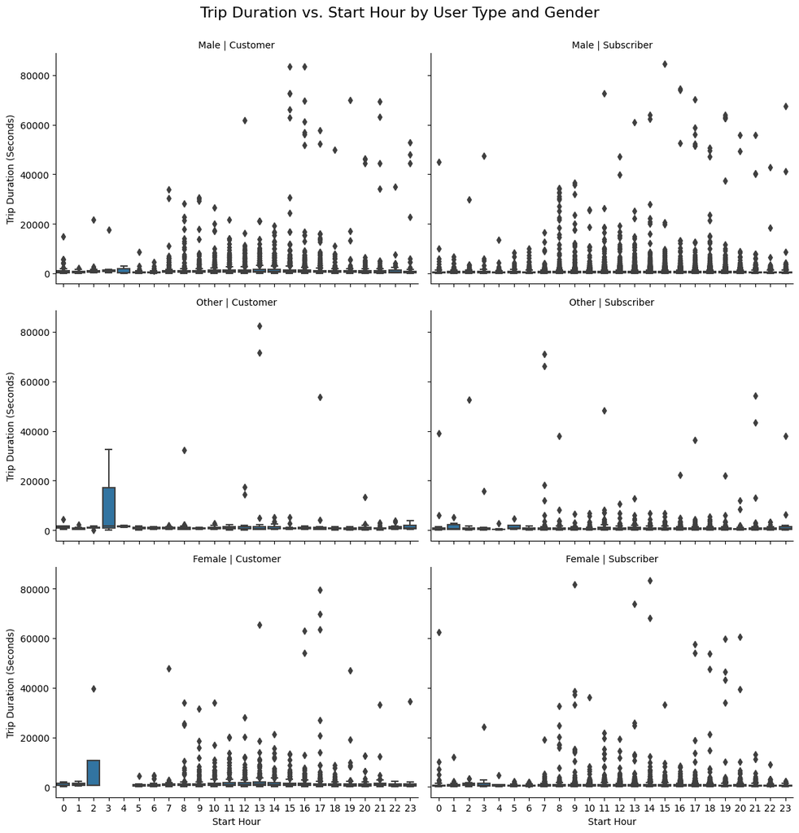

```python
df['start_time'] = pd.to_datetime(df['start_time'])
df['start_hour'] = df['start_time'].dt.hour

# Create a FacetGrid with three columns: User Type, Gender
g = sns.FacetGrid(data=df, col='user_type', row='member_gender', height=4, aspect=1.5)
g.map(sns.boxplot, 'start_hour', 'duration_sec', order=range(24))
g.set_axis_labels('Start Hour', 'Trip Duration (Seconds)')
g.set_titles(row_template='{row_name}', col_template='{col_name}')
plt.suptitle('Trip Duration vs. Start Hour by User Type and Gender', y=1.03, fontsize=16)
plt.show()
```

## Plot Matrix: Duration, Start Hour, and User Type

This matrix will show how trip duration relates to the start hour and user type.

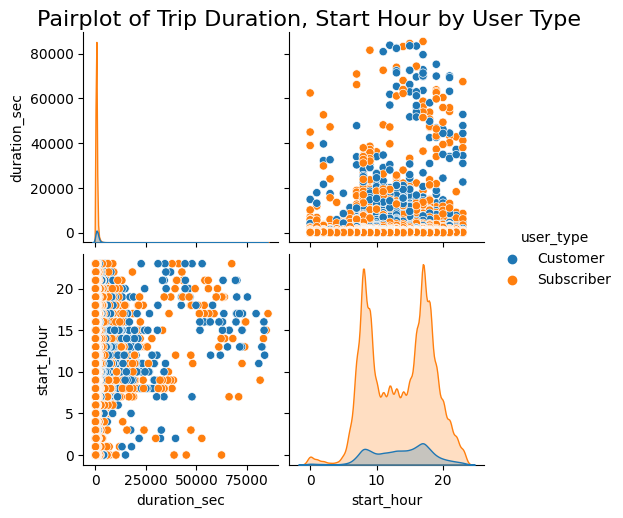

```python
sns.pairplot(df, vars=['duration_sec', 'start_hour'], hue='user_type', height=2.5)
plt.suptitle('Pairplot of Trip Duration, Start Hour by User Type', y=1.02, fontsize=16)
plt.show()
```

## Were there any interesting or surprising interactions between features?

One interesting interaction observed was between user type and trip duration. Subscribers generally tend to have shorter trip durations compared to Customers. This could be because Subscribers are more likely to use the service regularly for shorter, routine trips, whereas Customers may use it for longer, less frequent journeys. Additionally, the interaction between start hour and trip duration revealed that off-peak hours (e.g., late night and early morning) are associated with longer trip durations, which might be due to less traffic and more leisure trips.

These interactions highlight the importance of considering multiple factors when analyzing trip duration, as they collectively influence the outcomes in a way that might not be apparent when looking at each feature individually.

## ConclusionsSummary of Findings:

Trip Duration Patterns:

#### Reflection on the Data Exploration Process:

- The data exploration process involved systematically analyzing the dataset through univariate, bivariate, and multivariate analyses.
- During the univariate exploration, individual variables were examined to understand their distributions and identify any unusual points or outliers.
- The bivariate exploration focused on exploring relationships between pairs of variables, revealing how different features interact with trip duration and each other.
- The multivariate exploration further deepened the analysis by investigating how three or more variables interact, uncovering more complex relationships and dependencies.

This process helped in uncovering insights about user behavior and trip patterns, providing a more nuanced understanding of the factors that influence trip duration in bike-sharing systems.